# Central Limit Theorem Demonstration With Exponential Distributions

Fabiano A. Lima

august, 18th, 2015

# Introduction

On this document, we’re going to examine the Central Limit Theorem with Exponential Distribution. The Central Limit Theorem states that, on large number of iid samples, the distribution of the means tends to fit the normal distribution.

Some theoretical concepts are important about exponential distribution to understand this analysis.

- mean = `1/lambda`;
- variance = `1/lambda^2`
- sd = mean

# Sample Mean versus Theoretical Mean

In the case of the exponential distribution, the theoretical mean (the expected value, or E[X]) is 1/lambda, in our case, `1/0.2`, or 5.

Lets experiment and see how “fast”, samples of 40 observations drawn from a population with exponential distribution would center at E[X] for `lambda = 0.2`?

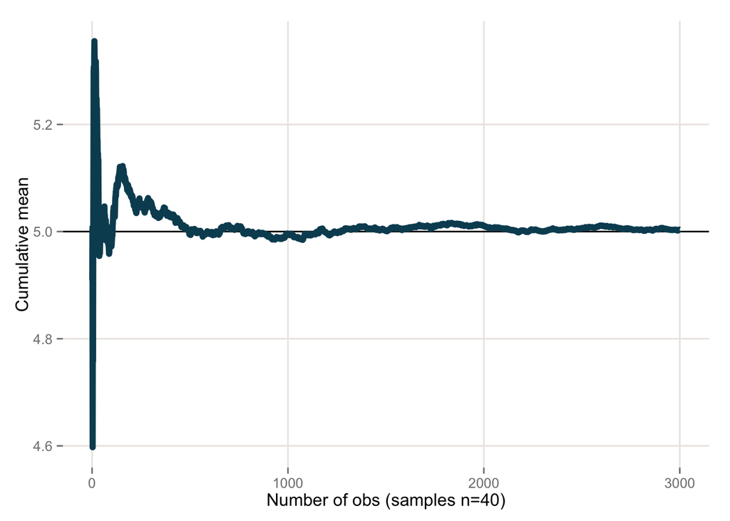

```r
n <- 3000

means <- cumsum(sapply(1:n, function(x) mean(rexp(n=obs, rate = r))))/(1:n)

g <- ggplot(data.frame(x = 1:n, y = means), aes(x = x, y = y))
g <- g + geom_hline(yintercept = 1/r) + geom_line(size = 2, color='#084C61')
g <- g + labs(x = "Number of obs (samples n=40)", y = "Cumulative mean")
g <- g + def_theme
#g <- g + annotate("text", x = 800, y = 6.9, label = paste("mean:",formatC(means[n - 1], digits = 2)))
g
```

As we see, the trend to center at E[X] is quite clear, and using the CLT will be probably a good approximation to work with data which has exponential distributions.

# Sample Variance versus Theoretical Variance

As we saw previously, the theoretical variance for a exponential distribution is `1/lambda^2`, in our case, 25.

To see how the samples variance compare to the theoretical variance, lets repeat the above simulation, but now, comparing the variance instead the mean.

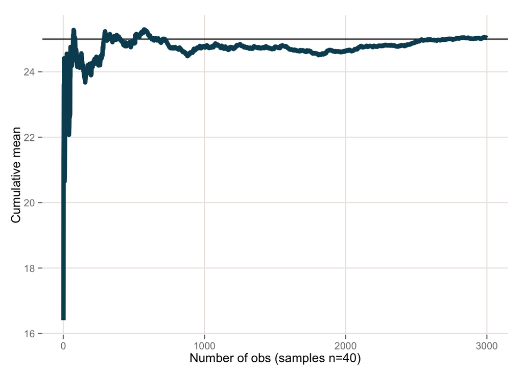

```r
n <- 3000

means <- cumsum(sapply(1:n, function(x) var(rexp(n=obs, rate = r))))/(1:n)

g <- ggplot(data.frame(x = 1:n, y = means), aes(x = x, y = y))
g <- g + geom_hline(yintercept = 1/r^2) + geom_line(size = 2, color='#084C61')
g <- g + labs(x = "Number of obs (samples n=40)", y = "Cumulative mean")
g <- g + def_theme
#g <- g + annotate("text", x = 800, y = 6.9, label = paste("mean:",formatC(means[n - 1], digits = 2)))
g
```

As we would expect, there is a clear trend for the variances to center at the theoretical mean.

# Distribution

Now, let’s compare how does this distribution fits the normal distribution as the samples increase. Let’s compare 10, 100, 1000 and 10000 samples.

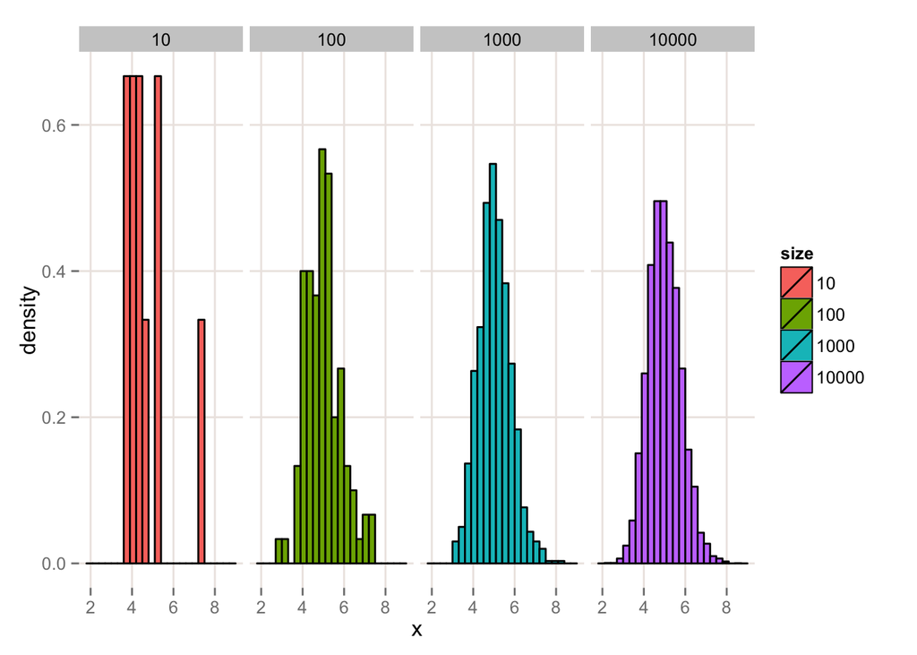

```r
dat <- data.frame(
  x = c (
    matrix(sapply(1:10, function(x) mean(rexp(n=obs, rate = r))), 10),
    matrix(sapply(1:100, function(x) mean(rexp(n=obs, rate = r))), 10),
    matrix(sapply(1:1000, function(x) mean(rexp(n=obs, rate = r))), 10),
    matrix(sapply(1:10000, function(x) mean(rexp(n=obs, rate = r))), 10)
  ),
  size = factor(c(rep(10,10), rep(100,100), rep(1000,1000), rep(10000,10000)))
)

g <- ggplot(dat, aes(x = x, fill = size)) +
      geom_histogram(binwidth=.3, colour = "black", aes(y = ..density..)) +
      #stat_function(fun = dnorm, size = 2, arg = list(mean = 1/r, sd = sqrt(1/r^2/obs))) +
      facet_grid(. ~ size) +
      def_theme
g
```

Now, lets do this same experiment, but normalizing the values so we can see if it fits the standard normal.

The theoretical variance for a exponential distribution is 1/lambda^2, and the standard deviation is equals to E[X] (ok, I didn’t know it, but I gave a look at https://en.wikipedia.org/wiki/Exponential_distribution).

So, the standard error would be `sqrt(Var(X)/n)`, in our case, `sqrt(1/r^2/n)`.

To show how the distribution fits a standard normal, we will draw a sample (40 obs, as always), subtract it’s mean from E[X], and divide by `sqrt(1/(r^2)/n)` - that is, the theoretical standard error for a exponential distribution, and see if it fits a standard normal. Let’s again compare 10, 100, 1000 and 10000 samples.

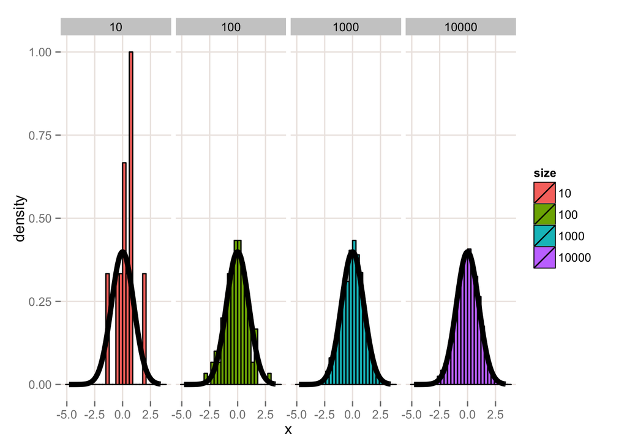

```r
dat <- data.frame(
  x = c (
    matrix(sapply(1:10, function(x) (1/r - mean(rexp(n=obs, rate = r)))/ sqrt(1/(r^2)/obs)), 10),
    matrix(sapply(1:100, function(x) (1/r - mean(rexp(n=obs, rate = r)))/ sqrt(1/(r^2)/obs)), 10),
    matrix(sapply(1:1000, function(x) (1/r - mean(rexp(n=obs, rate = r)))/ sqrt(1/(r^2)/obs)), 10),
    matrix(sapply(1:10000, function(x) (1/r - mean(rexp(n=obs, rate = r)))/ sqrt(1/(r^2)/obs)), 10)
  ),
  size = factor(c(rep(10,10), rep(100,100), rep(1000,1000), rep(10000,10000)))
)

g <- ggplot(dat, aes(x = x, fill = size)) +
      geom_histogram(binwidth=.3, colour = "black", aes(y = ..density..)) +
      stat_function(fun = dnorm, size = 2) +
      facet_grid(. ~ size) +
      def_theme
g
```

Now we can see that the shape of the distribution goes quite along with that of the standard normal.